# PEC 1. Análisis de datos ómicos.

Guillermo Prol Castelo

09/11/20

# I. Abstract.

In this microarray analysis, a study of the effect of chronic ethanol consumption on rat pancreas has been chosen (GEO reference *GSE3311*). In the following, the experiment, data and analysis workflow are described. An in-depth analysis of the microarray is carried out to find out whether there exist any differences between the control and treatment with ethanol groups. It is decided that such a significant difference exist: ethanol had an effect on gene expression.

# II. Objetivos.

Queremos saber si existen diferencias en la expresión genética del páncreas de aquellos ratones que siguieron una dieta con etanol.

# III. Materiales y métodos.

## III.1. Los datos.

Están disponibles a través del identificador *GSE3311* en *Gene Expression Omnibus (GEO)*. Se trata de un microarray de Affymetrix en el que se analizó la expresión de RNA de los grupos control y de tratamiento. El tratamiento corresponde a una dieta que incluye etanol. Ambas se suministraron a ratones ( *Rattus norvegicus*) durante 8 semanas.

El experimento se diseñó con dos factores, correspondientes al tipo de dieta: control y etanol. Cada tipo de dieta se repitió 3 veces, cada una en 6 ratones (macho) escogidos al azar en un determinado rango de peso (90-120 g). Podemos decir que el diseño del experimento es aleatorio (los factores o dietas se asignaron al azar a las unidades experimentales o ratones).

## III.2. Métodos.

Para analizar los datos del microarray hemos seguido un *workflow* que comienza por crear todas las carpetas necesarias en el fichero en que nos encontremos. A continuación, obtenemos los datos de GEO y extraemos los ficheros .CEL. Una vez importados a R, podemos explorar estos datos, realizar un control de calidad, normalizarlos y filtrarlos. Una vez hecho esto, podemos anotar los resultados, realizar comparaciones múltiples y un análisis de significación biológica.

## III.3. Librerías, directorios y funciones.

Comenzamos cargando todas las librerías que nos harán falta a lo largo del análisis.

```r
suppressMessages( library(Biobase) )
suppressMessages( library(GEOquery) )
suppressMessages( library(affy) )
suppressMessages( library(limma) )
suppressMessages( library(annotate) )
suppressMessages( library(annaffy) )
```

```r
suppressMessages( library(gplots) )
suppressMessages( library(genefilter) )
suppressMessages( library(oligo) )
suppressMessages( library(arrayQualityMetrics) )
suppressMessages( library(ggplot2) )
suppressMessages( library(ggrepel) )
suppressMessages( library(gmodels) )
suppressMessages( library(affyQCReport) )
```

Para facilitar el estudio, trabajaremos en un directorio escogido por nosotros y cuya localización se asigna a la variable `workingDir`. Los datos se copiarán en un subdirectorio del anterior denominado `data`, que se almacenará en la variable `dataDir` y los resultados se almacenarán en un directorio `results`, cuyo nombre se almacenará en la variable `resultsDir`. También creamos la carpeta `celfiles` para guardar en ella los ficheros .CEL.

```r
workingDir <- getwd()
# Creamos los directorios de datos y resultados:
system("mkdir data")
```

```
## [1] 1
```

```r
system("mkdir results")
```

```
## [1] 1
```

```r
system("mkdir celfiles")
```

```
## [1] 1
```

```r
# Los asignamos a variables:
dataDir <-file.path(workingDir, "data")
resultsDir <- file.path(workingDir, "results")
celfilesDir <- file.path(workingDir,"celfiles")
# Seleccionamos el directorio de trabajo:
setwd(workingDir)
```

Cargamos las funciones necesarias para el análisis.

```r
# Declaramos el directorio de funciones:
functionsDir <- file.path(workingDir, "functions/")
# Cargamos la función plotPCA.R
source(file.path(functionsDir,"plotPCA.R"))
```

# IV. Resultados

## IV.1. Obtención y lectura de los datos.

Comenzamos por obtener los datos desde *GEO Accession*:

```r
# Guardamos los datos en una variable en R:
gse <- getGEO("GSE3311", GSEMatrix = T, destdir = dataDir)
```

```
## Found 1 file(s)
```

```
## GSE3311_series_matrix.txt.gz
```

```
## Using locally cached version: C:/Users/G-mo10/Desktop/repos_ado/PEC1_ADO/data/GSE3311_series_matrix.txt.gz
```

```
## Using locally cached version of GPL341 found here:
## C:/Users/G-mo10/Desktop/repos_ado/PEC1_ADO/data/GPL341.soft
```

```r
# Descargamos los datos ('raw data') en la carpeta de datos:
a <- getGEOSuppFiles("GSE3311",makeDirectory = F, baseDir = dataDir)
```

Podemos explorar su contenido:

```r
rownames(pData(phenoData(gse[[1]])))
```

```
## [1] "GSM74493" "GSM74494" "GSM74495" "GSM74496" "GSM74497" "GSM74498"
```

```r
colnames(pData(phenoData(gse[[1]])))
```

```
##  [1] "title"                   "geo_accession"
##  [3] "status"                  "submission_date"
##  [5] "last_update_date"        "type"
##  [7] "channel_count"           "source_name_ch1"
##  [9] "organism_ch1"            "characteristics_ch1"
## [11] "molecule_ch1"            "extract_protocol_ch1"
## [13] "label_ch1"               "label_protocol_ch1"
## [15] "taxid_ch1"               "hyb_protocol"
## [17] "scan_protocol"           "description"
## [19] "data_processing"         "platform_id"
## [21] "contact_name"            "contact_email"
## [23] "contact_phone"           "contact_institute"
## [25] "contact_address"         "contact_city"
## [27] "contact_state"           "contact_zip/postal_code"
## [29] "contact_country"         "supplementary_file"
## [31] "data_row_count"
```

```r
head(pData(phenoData(gse[[1]])))
```

```
##                                        title geo_accession
## GSM74493 pancreas, control diet, replicate 1      GSM74493
## GSM74494 pancreas, control diet, replicate 2      GSM74494
## GSM74495 pancreas, control diet, replicate 3      GSM74495
## GSM74496 pancreas, ethanol diet, replicate 1      GSM74496
## GSM74497 pancreas, ethanol diet, replicate 2      GSM74497
## GSM74498 pancreas, ethanol diet, replicate 3      GSM74498
##                         status submission_date last_update_date type
## GSM74493 Public on Jul 01 2006     Sep 15 2005      Sep 15 2005  RNA
## GSM74494 Public on Jul 01 2006     Sep 15 2005      Sep 15 2005  RNA
## GSM74495 Public on Jul 01 2006     Sep 15 2005      Sep 15 2005  RNA
## GSM74496 Public on Jul 01 2006     Sep 15 2005      Sep 15 2005  RNA
## GSM74497 Public on Jul 01 2006     Sep 15 2005      Sep 15 2005  RNA
## GSM74498 Public on Jul 01 2006     Sep 15 2005      Sep 15 2005  RNA
##          channel_count source_name_ch1      organism_ch1
## GSM74493             1        pancreas Rattus norvegicus
## GSM74494             1        pancreas Rattus norvegicus
## GSM74495             1        pancreas Rattus norvegicus
## GSM74496             1        pancreas Rattus norvegicus
## GSM74497             1        pancreas Rattus norvegicus
## GSM74498             1        pancreas Rattus norvegicus
##                              characteristics_ch1 molecule_ch1
## GSM74493 pancreas, control diet, male Wistar rat    total RNA
## GSM74494 pancreas, control diet, male Wistar rat    total RNA
## GSM74495 pancreas, control diet, male Wistar rat    total RNA
## GSM74496 pancreas, ethanol diet, male Wistar rat    total RNA
## GSM74497 pancreas, ethanol diet, male Wistar rat    total RNA
## GSM74498 pancreas, ethanol diet, male Wistar rat    total RNA
##                                                                  extract_protocol_ch1
## GSM74493 Total RNA was extracted from the tissue lysate using an RNeasy kit (Qiagen).
## GSM74494 Total RNA was extracted from the tissue lysate using an RNeasy kit (Qiagen).
## GSM74495 Total RNA was extracted from the tissue lysate using an RNeasy kit (Qiagen).
## GSM74496 Total RNA was extracted from the tissue lysate using an RNeasy kit (Qiagen).
## GSM74497 Total RNA was extracted from the tissue lysate using an RNeasy kit (Qiagen).
## GSM74498 Total RNA was extracted from the tissue lysate using an RNeasy kit (Qiagen).
##          label_ch1
## GSM74493    biotin
## GSM74494    biotin
## GSM74495    biotin
## GSM74496    biotin
```

[output cut: 50 more lines]

```
## GSM74498    Ann Arbor            MI              48109-2029             USA
##                                                                      supplementary_file
## GSM74493 ftp://ftp.ncbi.nlm.nih.gov/geo/samples/GSM74nnn/GSM74493/suppl/GSM74493.CEL.gz
## GSM74494 ftp://ftp.ncbi.nlm.nih.gov/geo/samples/GSM74nnn/GSM74494/suppl/GSM74494.CEL.gz
## GSM74495 ftp://ftp.ncbi.nlm.nih.gov/geo/samples/GSM74nnn/GSM74495/suppl/GSM74495.CEL.gz
## GSM74496 ftp://ftp.ncbi.nlm.nih.gov/geo/samples/GSM74nnn/GSM74496/suppl/GSM74496.CEL.gz
## GSM74497 ftp://ftp.ncbi.nlm.nih.gov/geo/samples/GSM74nnn/GSM74497/suppl/GSM74497.CEL.gz
## GSM74498 ftp://ftp.ncbi.nlm.nih.gov/geo/samples/GSM74nnn/GSM74498/suppl/GSM74498.CEL.gz
##          data_row_count
## GSM74493          15923
## GSM74494          15923
## GSM74495          15923
## GSM74496          15923
## GSM74497          15923
## GSM74498          15923
```

Vemos que los tres primeros ficheros CEL corresponden al tratamiento control y los otros tres al tratamiento con etanol.

```r
# get info from gse
filedata <- pData(phenoData(gse[[1]]))
sampleNames <- rownames(filedata)
# get dataframe with .CEL files names:
file_to_txt <- data.frame(file_name=paste(sampleNames,'.CEL',sep=''),dataDir,filedata)
# Creamos una tabla con las muestras seleccionadas:
write.table(file_to_txt,
            file=file.path(dataDir, "targets.txt"),
            sep="\t",
            row.names=FALSE,
            quote=FALSE)
```

```r
# Directory the .tar was saved to:
unpackDir <-  celfilesDir
# Decompress .tar file:
#untar(file.path(dataDir, 'GSE3311_RAW.tar'), exdir = celfilesDir)
# Delete .tar file:
#file.remove(file.path(unpackDir, 'GSE18198_RAW.tar'))

# Decompress all .gz files in our directory:
#for (i in list.files(unpackDir)) {
#  gunzip(file.path(unpackDir, i))
#}
```

Lectura de datos (los cargamos en R):

```r
#require(Biobase)
sampleInfo <-read.AnnotatedDataFrame(
  file.path(dataDir,"targets.txt"),
  header = TRUE, row.names = 1)
show(pData(sampleInfo))
```

```
##                                                      dataDir
## GSM74493.CEL C:/Users/G-mo10/Desktop/repos_ado/PEC1_ADO/data
## GSM74494.CEL C:/Users/G-mo10/Desktop/repos_ado/PEC1_ADO/data
## GSM74495.CEL C:/Users/G-mo10/Desktop/repos_ado/PEC1_ADO/data
## GSM74496.CEL C:/Users/G-mo10/Desktop/repos_ado/PEC1_ADO/data
## GSM74497.CEL C:/Users/G-mo10/Desktop/repos_ado/PEC1_ADO/data
## GSM74498.CEL C:/Users/G-mo10/Desktop/repos_ado/PEC1_ADO/data
##                                            title geo_accession
## GSM74493.CEL pancreas, control diet, replicate 1      GSM74493
## GSM74494.CEL pancreas, control diet, replicate 2      GSM74494
## GSM74495.CEL pancreas, control diet, replicate 3      GSM74495
## GSM74496.CEL pancreas, ethanol diet, replicate 1      GSM74496
## GSM74497.CEL pancreas, ethanol diet, replicate 2      GSM74497
## GSM74498.CEL pancreas, ethanol diet, replicate 3      GSM74498
##                             status submission_date last_update_date type
## GSM74493.CEL Public on Jul 01 2006     Sep 15 2005      Sep 15 2005  RNA
## GSM74494.CEL Public on Jul 01 2006     Sep 15 2005      Sep 15 2005  RNA
## GSM74495.CEL Public on Jul 01 2006     Sep 15 2005      Sep 15 2005  RNA
## GSM74496.CEL Public on Jul 01 2006     Sep 15 2005      Sep 15 2005  RNA
## GSM74497.CEL Public on Jul 01 2006     Sep 15 2005      Sep 15 2005  RNA
## GSM74498.CEL Public on Jul 01 2006     Sep 15 2005      Sep 15 2005  RNA
##              channel_count source_name_ch1      organism_ch1
## GSM74493.CEL             1        pancreas Rattus norvegicus
## GSM74494.CEL             1        pancreas Rattus norvegicus
## GSM74495.CEL             1        pancreas Rattus norvegicus
## GSM74496.CEL             1        pancreas Rattus norvegicus
## GSM74497.CEL             1        pancreas Rattus norvegicus
## GSM74498.CEL             1        pancreas Rattus norvegicus
##                                  characteristics_ch1 molecule_ch1
## GSM74493.CEL pancreas, control diet, male Wistar rat    total RNA
## GSM74494.CEL pancreas, control diet, male Wistar rat    total RNA
## GSM74495.CEL pancreas, control diet, male Wistar rat    total RNA
## GSM74496.CEL pancreas, ethanol diet, male Wistar rat    total RNA
## GSM74497.CEL pancreas, ethanol diet, male Wistar rat    total RNA
## GSM74498.CEL pancreas, ethanol diet, male Wistar rat    total RNA
##                                                                      extract_protocol_ch1
## GSM74493.CEL Total RNA was extracted from the tissue lysate using an RNeasy kit (Qiagen).
## GSM74494.CEL Total RNA was extracted from the tissue lysate using an RNeasy kit (Qiagen).
## GSM74495.CEL Total RNA was extracted from the tissue lysate using an RNeasy kit (Qiagen).
## GSM74496.CEL Total RNA was extracted from the tissue lysate using an RNeasy kit (Qiagen).
```

[output cut: 57 more lines]

```
## GSM74498.CEL    Ann Arbor            MI              48109-2029             USA
##                                                                          supplementary_file
## GSM74493.CEL ftp://ftp.ncbi.nlm.nih.gov/geo/samples/GSM74nnn/GSM74493/suppl/GSM74493.CEL.gz
## GSM74494.CEL ftp://ftp.ncbi.nlm.nih.gov/geo/samples/GSM74nnn/GSM74494/suppl/GSM74494.CEL.gz
## GSM74495.CEL ftp://ftp.ncbi.nlm.nih.gov/geo/samples/GSM74nnn/GSM74495/suppl/GSM74495.CEL.gz
## GSM74496.CEL ftp://ftp.ncbi.nlm.nih.gov/geo/samples/GSM74nnn/GSM74496/suppl/GSM74496.CEL.gz
## GSM74497.CEL ftp://ftp.ncbi.nlm.nih.gov/geo/samples/GSM74nnn/GSM74497/suppl/GSM74497.CEL.gz
## GSM74498.CEL ftp://ftp.ncbi.nlm.nih.gov/geo/samples/GSM74nnn/GSM74498/suppl/GSM74498.CEL.gz
##              data_row_count
## GSM74493.CEL          15923
## GSM74494.CEL          15923
## GSM74495.CEL          15923
## GSM74496.CEL          15923
## GSM74497.CEL          15923
## GSM74498.CEL          15923
```

El contenido del archivo targets se utiliza en la lectura de los datos y la creación del objeto rawData de la clase `affybatch` que contendrá las intensidades “crudas” de cada archivo .CEL.

```r
fileNames <- rownames(pData(sampleInfo))
rawData <- read.affybatch(filenames=file.path(celfilesDir,fileNames),
                          phenoData=sampleInfo)
show(rawData)
```

```
## AffyBatch object
## size of arrays=602x602 features (33 kb)
## cdf=RAE230A (15923 affyids)
## number of samples=6
## number of genes=15923
## annotation=rae230a
## notes=
```

## IV.2. Exploración, control de calidad y normalización.

Veamos los nombres de cada muestra.

```r
sampleNames <- filedata$title
sampleNames
```

```
## [1] "pancreas, control diet, replicate 1" "pancreas, control diet, replicate 2"
## [3] "pancreas, control diet, replicate 3" "pancreas, ethanol diet, replicate 1"
## [5] "pancreas, ethanol diet, replicate 2" "pancreas, ethanol diet, replicate 3"
```

Como son muy largos para utilizarlos directamente en los siguientes gráficos, simplificaremos sus nombres:

```r
sampleNames <- c('Control_1','Control_2','Control_3','Ethanol_1','Ethanol_3','Ethanol_3')
sampleNames
```

```
## [1] "Control_1" "Control_2" "Control_3" "Ethanol_1" "Ethanol_3" "Ethanol_3"
```

Una forma más computacional de crear este vector sería la siguiente:

```r
dummy_control <- c()
for (i in 1:3) {
  dummy_control <- c(dummy_control,paste('Control_',as.character(i),sep = ''))
}

dummy_ethanol <- c()
for (i in 1:3) {
  dummy_ethanol <- c(dummy_ethanol,paste('Ethanol_',as.character(i),sep = ''))
}

sampleNames <- c(dummy_control,dummy_ethanol)
sampleNames
```

```
## [1] "Control_1" "Control_2" "Control_3" "Ethanol_1" "Ethanol_2" "Ethanol_3"
```

Podemos visualizar los datos con varios tipos de gráficos.

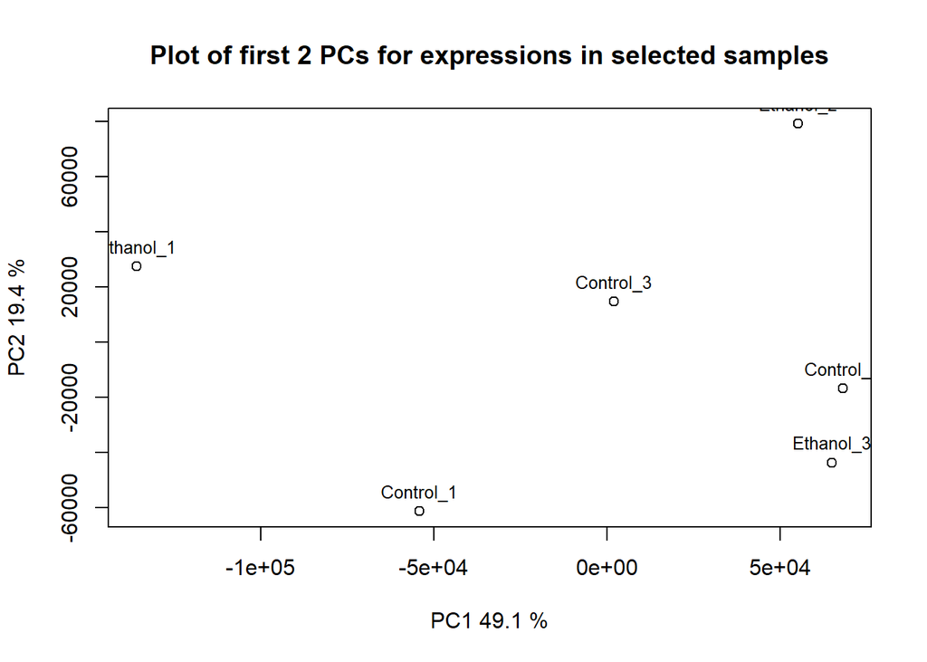

```r
plotPCA(exprs(rawData), labels=sampleNames, dataDesc="selected samples")
```

Distribución de señales:

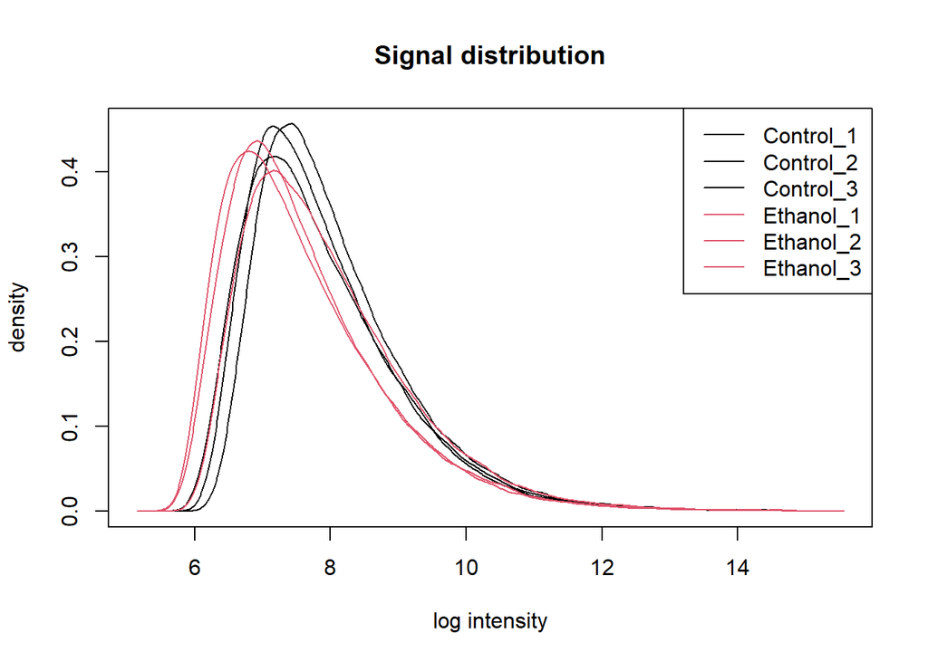

```r
info <- data.frame(grupo=c(1,1,1,2,2,2))

hist(rawData, main="Signal distribution", col=info$grupo, lty=1:ncol(info))
legend (x="topright",
        legend=sampleNames,#c(rep('Control',3),rep('Ethanol',3)) ,
        col=info$grupo, lty=1:ncol(info)
        )
```

Boxplot:

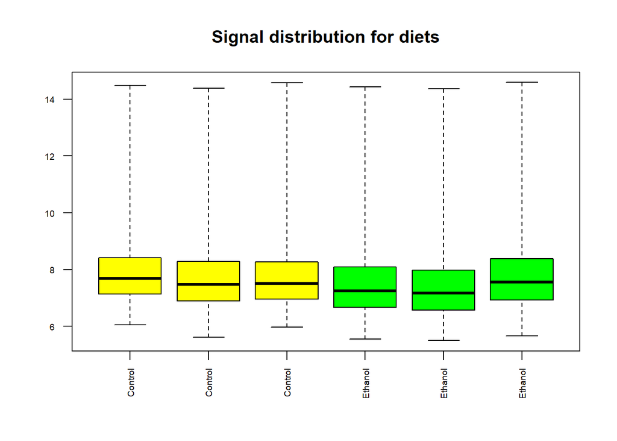

```r
colores <- c(rep("yellow", 3), rep("green", 3))
boxplot(rawData, cex.axis=0.6, col=colores, las=2,
        names=c(rep('Control',3),rep('Ethanol',3)),
        main="Signal distribution for diets")
```

Heatmap:

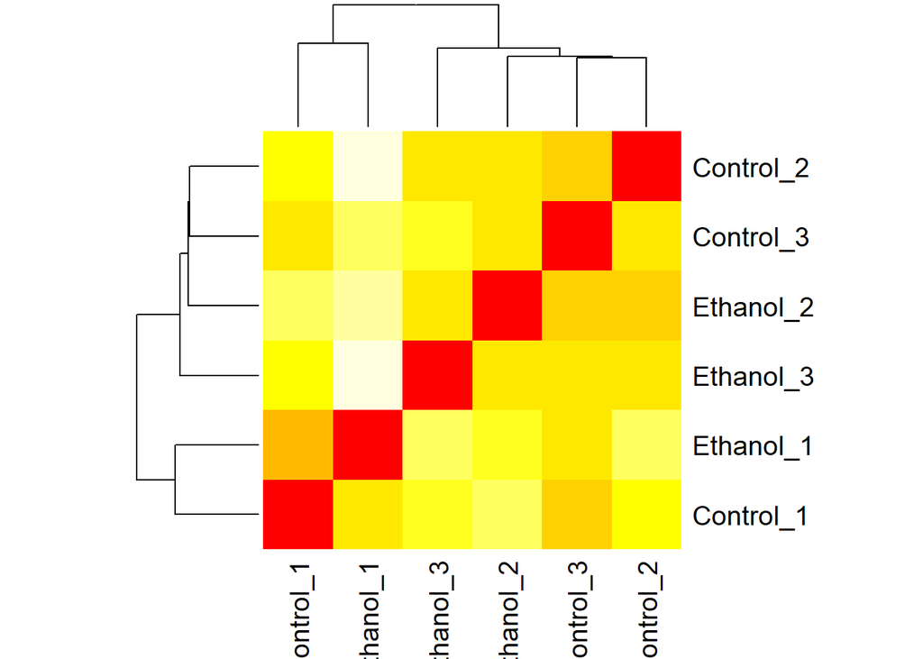

```r
#heatmap:
manDist <-  dist(t(exprs(rawData)))
heatmap (as.matrix(manDist),  col=heat.colors(16),
         labRow = sampleNames, labCol = sampleNames)
```

Dendrograma:

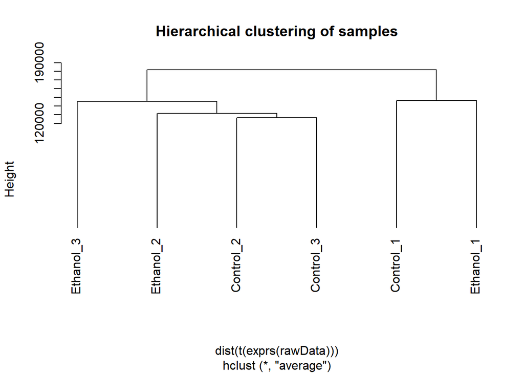

```r
## ----plotDendro
clust.euclid.average <- hclust(dist(t(exprs(rawData))),method="average")
plot(clust.euclid.average, labels=sampleNames, main="Hierarchical clustering of samples",  hang=-1)
```

### IV.2.1. Control de calidad.

El paquete affyQCReport encapsula los análisis que pueden realizarse con el paquete simpleaffy, de forma que con una instrucción se pueden realizar todos los análisis y enviar la salida a un archivo.

```r
stopifnot(require(affyQCReport))
QCReport(rawData,file=file.path(resultsDir,"QCReport.pdf"))
```

```
## [1] TRUE
```

El paquete affyPLM realiza un control de calidad basado en lo que se conoce como modelos a nivel de sonda o probe-level models, conocidos por sus siglas (PLM).

```r
stopifnot(require(affyPLM))
computePLM <- T
if(computePLM){
  Pset<- fitPLM(rawData)
  save(Pset, file=file.path(dataDir,"PLM.Rda"))
}else{
  load (file=file.path(dataDir,"PLM.Rda"))
}
```

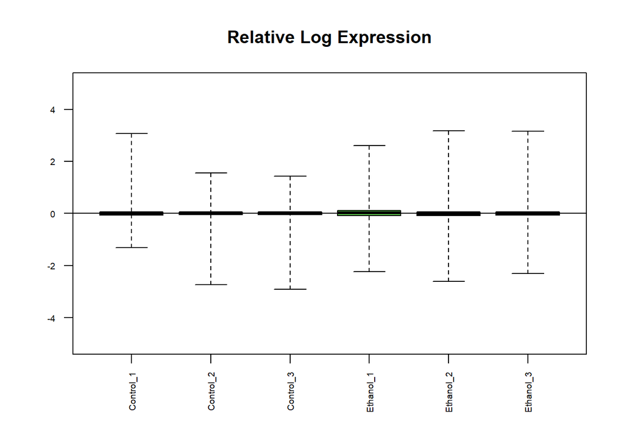

```r
RLE(Pset, main = "Relative Log Expression", names=sampleNames, las=2, col=info$grupo+1, cex.axis=0.6,ylim=c(-5,5))
```

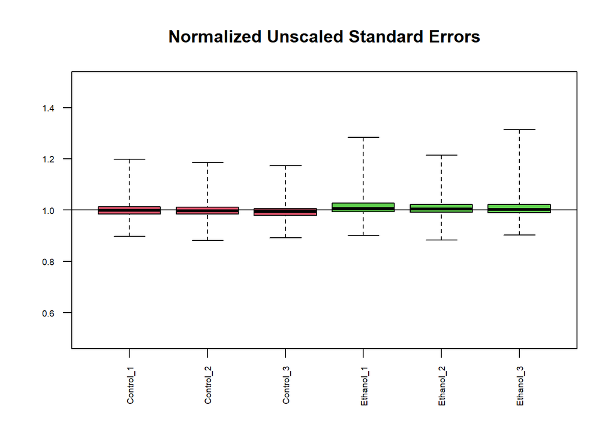

```r
NUSE(Pset, main = "Normalized Unscaled Standard Errors", las=2, names=sampleNames, col=info$grupo+1, cex.axis=0.6, ylim=c(0.5,1.5))
```

### IV.2.2. Normalización.

El procesado mediante RMA implica un proceso en tres etapas:

- Corrección de fondo (el RMA hace precisamente esto).
- Normalización para hacer los valores de los arrays comparables.
- Resumen (sumarización) de las diversas sondas asociadas a cada grupo de sondas para dar un único valor.

```r
stopifnot(require(affy))
normalize <- T
if(normalize){
  eset_rma <- affy::rma(rawData)
  save(eset_rma, file=file.path(dataDir,"normalized.Rda"))
}else{
  load (file=file.path(dataDir,"normalized.Rda"))
}
```

```
## Background correcting
## Normalizing
## Calculating Expression
```

Un boxplot de los valores normalizados sugiere que los valores ya están en una escala en donde se pueden comparar.

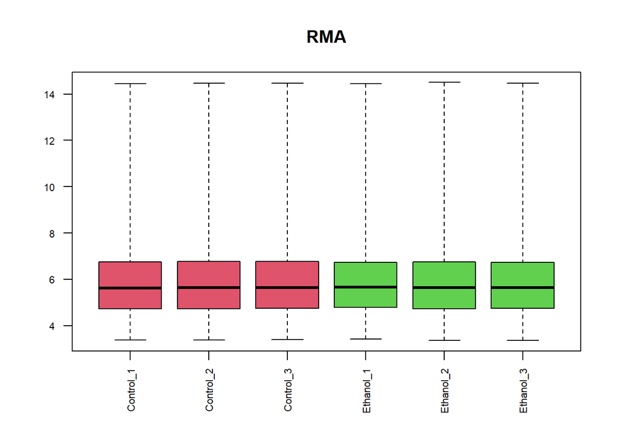

```r
boxplot(eset_rma,main="RMA", names=sampleNames, cex.axis=0.7, col=info$grupo+1,las=2)
```

El paquete affyQCReport encapsula los análisis que pueden realizarse con el paquete simpleaffy, de forma que con una instrucción se pueden realizar todos los análisis y enviar la salida a un archivo.

```r
# Guardamos el informe en el fichero de resultados:
#QCReport(ReadAffy(eset_rma),file=file.path(resultsDir,"QCReport_normalized.pdf"))
```

El paquete affyPLM realiza un control de calidad basado en lo que se conoce como modelos a nivel de sonda o probe-level models, conocidos por sus siglas (PLM).

```r
#stopifnot(require(affyPLM))
#computePLM <- T
#if(computePLM){
#  Pset<- fitPLM(eset_rma)
#  save(Pset, file=file.path(dataDir,"PLM_normalized.Rda"))
#}else{
#  load (file=file.path(dataDir,"PLM_normalized.Rda"))
#}
```

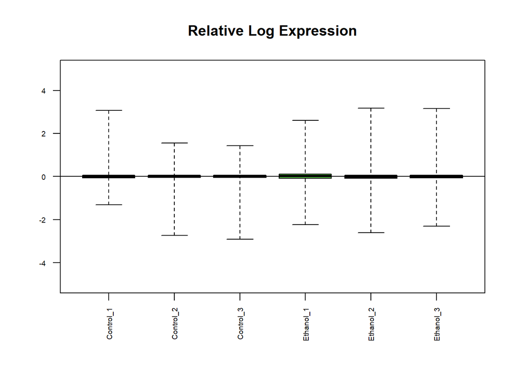

```r
RLE(Pset, main = "Relative Log Expression", names=sampleNames, las=2, col=info$grupo+1, cex.axis=0.6,ylim=c(-5,5))
```

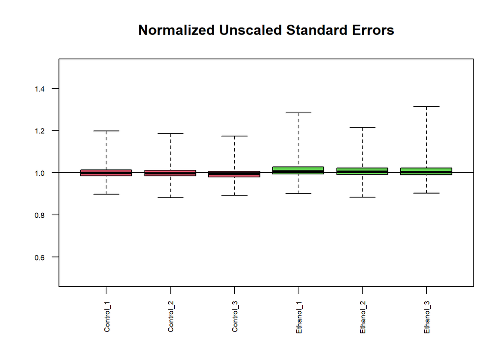

```r
NUSE(Pset, main = "Normalized Unscaled Standard Errors", las=2, names=sampleNames, col=info$grupo+1, cex.axis=0.6, ylim=c(0.5,1.5))
```

### IV.2.4. Filtraje.

El filtraje no específico permite eliminar los genes que varían poco entre condiciones o que deseamos quitar por otras razones, como por ejemplo que no disponemos de anotación para ellos. La función nsFilter permite eliminar los genes que, o bien varían poco, o bien no se dispone de anotación para ellos.

Si al filtrar deseamos usar las anotaciones, o la falta de ellas, como criterio de filtraje, debemos disponer del correspondiente paquete de anotaciones.

En nuestro caso, tenemos que instalar el paquete ‘rae230a.db’:

```r
if (!requireNamespace("BiocManager", quietly = TRUE))
    install.packages("BiocManager")

BiocManager::install("rae230a.db")
filtered <- nsFilter(eset_rma, require.entrez=TRUE,
                     remove.dupEntrez=TRUE, var.func=IQR,
                     var.cutoff=0.5, var.filter=TRUE,
                     filterByQuantile=TRUE, feature.exclude="^AFFX")
class(filtered)
```

```
## [1] "list"
```

```r
names(filtered)
```

```
## [1] "eset"       "filter.log"
```

```r
dim(exprs(filtered$eset))
```

```
## [1] 5226    6
```

La función `nsFilter` devuelve los valores filtrados en un objeto `expressionSet` y un informe de los resultados del filtraje.

```r
class(filtered$eset)
```

```
## [1] "ExpressionSet"
## attr(,"package")
## [1] "Biobase"
```

```r
print(filtered$filter.log)
```

```
## $numDupsRemoved
## [1] 2347
##
## $numLowVar
## [1] 5227
##
## $numRemoved.ENTREZID
## [1] 3117
##
## $feature.exclude
## [1] 6
```

```r
eset_filtered <-filtered$eset
```

Podemos grabar el objeto `eset_rma` y los datos filtrados para su posterior uso.

```r
# Guardamos en el directorio de resultados:
save(eset_rma, eset_filtered, file=file.path(resultsDir, "estrogen-normalized.Rda"))
```

## IV.3. Selección de genes diferencialmente expresados.

### IV.3.1. Análisis basado en modelos lineales.

**Matriz de diseño**:

Manualmente:

Tomamos como modelo lineal el siguiente:
$$Y_{ij}=\alpha_i + \epsilon_{ij}$$

Donde $\alpha_i$ tiene en cuenta el tipo de tratamiento, es decir:
$$\left\{\begin{matrix}
\alpha_1=(Control)\\
\alpha_2=(Ethanol)\\
\end{matrix}\right.$$

Por tanto, la matriz de diseño es:
$$\begin{pmatrix}
1 & 0 \\
1 & 0 \\
1 & 0 \\
0 & 1 \\
0 & 1 \\
0 & 1 \\
\end{pmatrix}$$
La escribimos en forma de código:

```r
design.1<-matrix(
c(1,1,1,0,0,0,
  0,0,0,1,1,1),
nrow=6,
byrow=F)
colnames(design.1)<-c("Control", "Ethanol")
rownames(design.1) <-  sampleNames
print(design.1)
```

```
##           Control Ethanol
## Control_1       1       0
## Control_2       1       0
## Control_3       1       0
## Ethanol_1       0       1
## Ethanol_2       0       1
## Ethanol_3       0       1
```

Computacionalmente, utilizando el paquete `limma`.

```r
if (!exists("eset_rma"))  load(file.path(dataDir, "normalized.rda"))
targets <- pData(eset_rma)
```

```r
lev<-factor(c(rep('Control',3),rep('Ethanol',3)),
            levels=c('Control','Ethanol')
            )
design <-model.matrix(~0+lev)
colnames(design)<-levels(lev)
rownames(design) <- sampleNames
print(design)
```

```
##           Control Ethanol
## Control_1       1       0
## Control_2       1       0
## Control_3       1       0
## Ethanol_1       0       1
## Ethanol_2       0       1
## Ethanol_3       0       1
## attr(,"assign")
## [1] 1 1
## attr(,"contrasts")
## attr(,"contrasts")$lev
## [1] "contr.treatment"
```

Vemos que coincide con nuestra propuesta.

**Contrastes**:

En este caso, nos interesa estudiar el efecto del etanol en la dieta de los ratones, es decir, la diferencia entre la dieta con etanol y la dieta control.

Lo podemos formular como:
$$\beta=\alpha_2-\alpha_1 \rightarrow efecto\; del \; etanol$$
La matriz de contraste correspondiente es, simplemente:

$$\bigl(\begin{smallmatrix}
1 & -1
\end{smallmatrix}\bigr)$$
Esta se puede hallar también de forma computacional:

```r
cont.matrix <- makeContrasts (
  Diet = Ethanol - Control,
  levels=design
  )
cont.matrix
```

```
##          Contrasts
## Levels    Diet
##   Control   -1
##   Ethanol    1
```

También coincide con nuestra matriz de contraste.

**Estimación del modelo y selección de genes.**

Una vez definida la matriz de diseño y los contrastes, podemos pasar a estimar el modelo, estimar los contrastes y realizar las pruebas de significación que nos indiquen, para cada gen y cada comparación, si puede considerarse diferencialmente expresado.

El análisis proporciona los estadísticos de test habituales como *Fold-change*, t-moderados o p-valores ajustados, que se utilizan para ordenar los genes de más a menos diferencialmente expresados.

La función `topTable` genera para cada contraste una lista de genes ordenados de más a menos diferencialmente expresados.

```r
# Linear model fit:

fit<-lmFit(eset_rma, design)
fit.main<-contrasts.fit(fit, cont.matrix)
fit.main<-eBayes(fit.main)
```

```r
topTab  <- topTable (fit.main, number=nrow(fit.main) , coef="Diet", adjust="fdr")
```

Una forma de visualizar los resultados es mediante un *volcano plot*, que representa en abscisas los cambios de expresión en escala logarítmica, y en ordenadas el “menos logaritmo” del p-valor o alternativamente el estadístico B. Los genes cuyo *log odds* es superior a 0 y cuyo *log fold change* es, en valor absoluto, superior a 1, son candidatos a estar diferencialmente expresados.

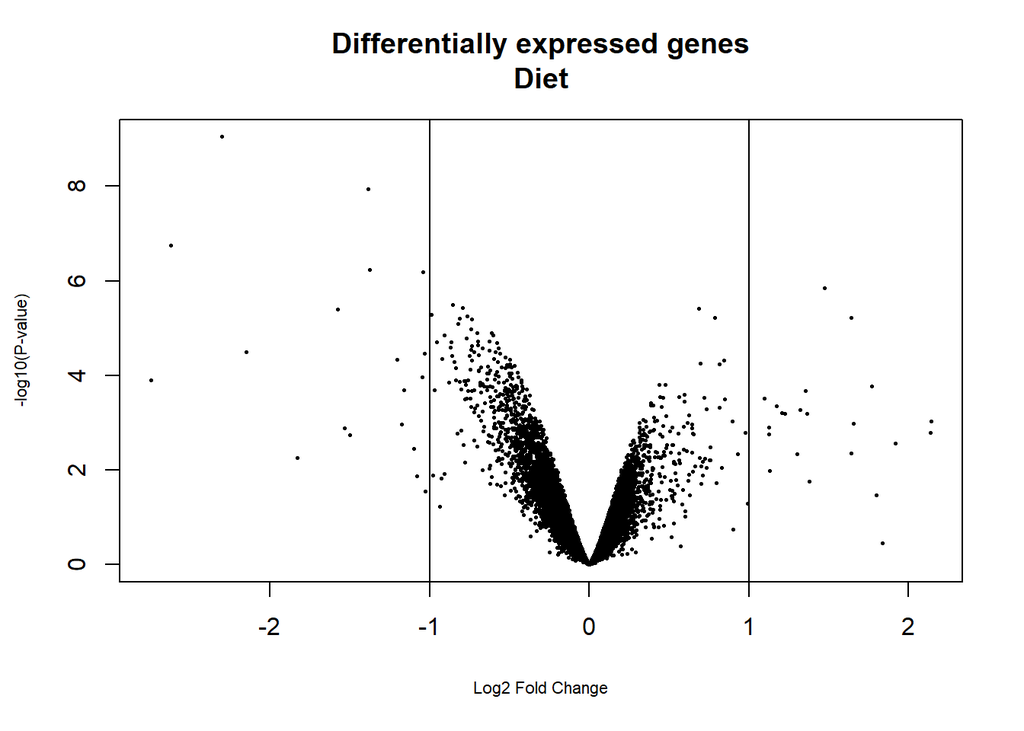

```r
coefnum = 1
opt <- par(cex.lab = 0.7)
volcanoplot(fit.main, coef=coefnum, highlight=0, names=rownames(fit.main),
            main=paste("Differentially expressed genes",colnames(cont.matrix)[coefnum], sep="\n"))
abline(v=c(-1,1))
```

Vemos que hay varios puntos a la izquierda de -1 y a la derecha de 1.

### IV.3.2. Comparaciones múltiples.

Cuando se realizan varias comparaciones a la vez puede resultar importante ver qué genes cambian simultáneamente en más de una comparación. Si el número de comparaciones es alto, también puede ser necesario realizar un ajuste de p-valores entre las comparaciones, distinto del realizado entre genes.

La función `decidetests` permite realizar ambas cosas. En este caso no se ajustarán los p-valores entre comparaciones. Tan solo se seleccionarán los genes que cambian en una o más condiciones.

El resultado del análisis es una tabla, que llamaremos `res` y que para cada gen y cada comparación contiene un 1 (si el gen esta sobreexpresado o *up* en esta condición), un 0 (si no hay cambio significativo) o un -1 (si está *down* regulado).

```r
require('rae230a.db')
anotPackage <- annotation(eset_rma)
fit.Symbols <- getSYMBOL (rownames(fit.main), anotPackage)
res<-decideTests(fit.main, method="separate", adjust.method="fdr", p.value=0.01)
```

```r
sum.res.rows<-apply(abs(res),1,sum)
res.selected<-res[sum.res.rows!=0,]
print(summary(res))
```

```
##         Diet
## Down      14
## NotSig 15905
## Up         4
```

### IV.3.3. Anotación de resultados.

Para saber qué anotaciones están disponibles, debe cargarse el paquete y llamar la función del mismo nombre.

```r
rae230a()
```

```
## Quality control information for rae230a:
##
##
## This package has the following mappings:
##
## rae230aACCNUM has 15923 mapped keys (of 15923 keys)
## rae230aALIAS2PROBE has 19462 mapped keys (of 64537 keys)
## rae230aCHR has 12804 mapped keys (of 15923 keys)
## rae230aCHRLENGTHS has 953 mapped keys (of 953 keys)
## rae230aCHRLOC has 11680 mapped keys (of 15923 keys)
## rae230aCHRLOCEND has 11680 mapped keys (of 15923 keys)
## rae230aENSEMBL has 12146 mapped keys (of 15923 keys)
## rae230aENSEMBL2PROBE has 9971 mapped keys (of 21000 keys)
## rae230aENTREZID has 12810 mapped keys (of 15923 keys)
## rae230aENZYME has 1989 mapped keys (of 15923 keys)
## rae230aENZYME2PROBE has 814 mapped keys (of 960 keys)
## rae230aGENENAME has 12810 mapped keys (of 15923 keys)
## rae230aGO has 12106 mapped keys (of 15923 keys)
## rae230aGO2ALLPROBES has 18932 mapped keys (of 22754 keys)
## rae230aGO2PROBE has 14506 mapped keys (of 18279 keys)
## rae230aPATH has 4832 mapped keys (of 15923 keys)
## rae230aPATH2PROBE has 225 mapped keys (of 225 keys)
## rae230aPMID has 10955 mapped keys (of 15923 keys)
## rae230aPMID2PROBE has 84668 mapped keys (of 157386 keys)
## rae230aREFSEQ has 12800 mapped keys (of 15923 keys)
## rae230aSYMBOL has 12810 mapped keys (of 15923 keys)
## rae230aUNIGENE has 11999 mapped keys (of 15923 keys)
## rae230aUNIPROT has 11757 mapped keys (of 15923 keys)
##
##
## Additional Information about this package:
##
## DB schema: RATCHIP_DB
## DB schema version: 2.1
## Organism: Rattus norvegicus
## Date for NCBI data: 2015-Sep27
## Date for GO data: 20150919
## Date for KEGG data: 2011-Mar15
## Date for Golden Path data: 2014-Aug1
## Date for Ensembl data: 2015-Jul16
```

**Tablas de anotación sencillas.**

El paquete `annafy` permite de forma muy simple generar una tabla de anotaciones con hiperenlaces a las bases de datos para cada anotación seleccionada.

```r
#require(annaffy)
genesSelected <- rownames(res.selected)
at <- aafTableAnn(genesSelected, "rae230a.db")
saveHTML (at, file.path(resultsDir, "anotations.html"),
          "Annotations for selected genes")
```

### IV.3.4. Visualización de los perfiles de expresión.

Tras seleccionar los genes diferencialmente expresados, podemos visualizar las expresiones de cada gen agrupándolas para destacar los genes que se encuentran up o down regulados simultáneamente constituyendo perfiles de expresión.

Hay distintas formas de visualización, pero aquí tan solo se presenta el uso de mapas de color o Heatmaps.

```r
probeNames<-rownames(res)
probeNames.selected<-probeNames[sum.res.rows!=0]
exprs2cluster <-exprs(eset_rma)[probeNames.selected,]
```

Para representar el Heatmap solo necesitamos la matriz de datos resultante.

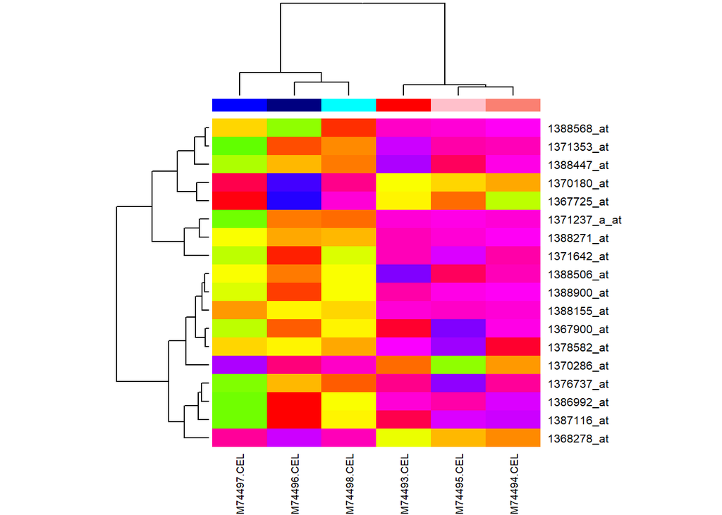

```r
grupColors <- c('red','salmon','pink','navy','blue','cyan')
heatmap(exprs2cluster, col=rainbow(100), ColSideColors=grupColors, cexCol=0.9)
```

Si se desea realizar mapas de color más sofisticados, puede utilizarse el paquete gplots que implementa una versión mejorada en la función `heatmap.2`.

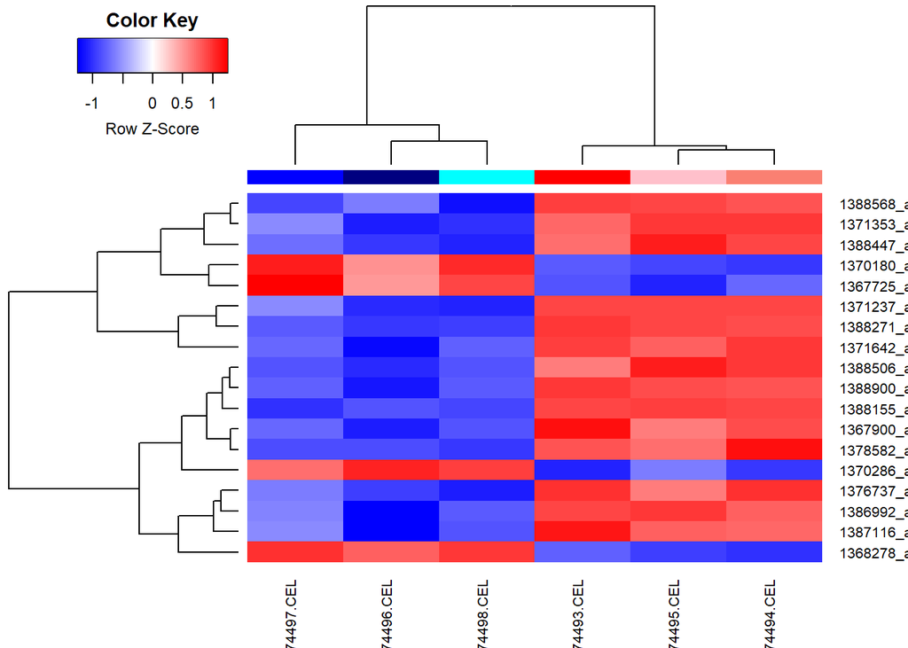

```r
#grupColors <- unlist(lapply(pData(eset_rma)$dataDir, color.map))

#require("gplots")

heatmap.2(exprs2cluster,
          col=bluered(75), scale="row",
          ColSideColors=grupColors, key=TRUE, symkey=FALSE,
          density.info="none", trace="none", cexCol=1)
```

### IV.3.5. Análisis de significación biológica.

Vamos a estudiar las funciones de los genes buscando sus anotaciones en bases de datos de anotación funcional como la Gene Ontology (GO).

Antes de empezar a hacer inferencias sobre el significado de una anotación debería poderse establecer si dicha anotación está relacionada con el proceso que se está estudiando o aparece por azar entre la muchas anotaciones de losgenes de la lista.

Para ello, realizamos un análisis de enriquecimiento con Bioconductor.

```r
 require(GOstats)
 require(rae230a.db)


   # Seleccionamos la "topTable"
   topTab <- topTab
   # Definimos el universo de genes: todos los que se han incluido en el analisis
   # EL programa trabaja con identificadores "entrez" y no admite duplicados

   entrezUniverse <- unique(getEG(as.character(rownames(topTab)), "rae230a.db"))

   # Filtramos posibles NA:
   entrezUniverse <- entrezUniverse[!is.na(entrezUniverse)]

   # Escogemos los grupos de sondas a incluir en el analisis
   # Este analisis trabaja bien con varios centenares de genes
   # por lo que es habitual basarse en p-valores sin ajustar para incluirlos

   whichGenes<-topTab["adj.P.Val"]<0.001
   geneIds <-   unique(getEG(as.character(rownames(topTab)[whichGenes[,1]]),"rae230a.db"))

   # Filtramos posibles NA:
   geneIds <- geneIds[!is.na(geneIds)]

   # Creamos los "hiperparametros" en que se basa el analisis
   GOparams = new("GOHyperGParams",
     geneIds=geneIds, universeGeneIds=entrezUniverse,
     annotation="rae230a.db", ontology="BP",
     pvalueCutoff=0.001, conditional=FALSE,
     testDirection="over")
   KEGGparams = new("KEGGHyperGParams",
     geneIds=geneIds, universeGeneIds=entrezUniverse,
     annotation="rae230a.db",
     pvalueCutoff=0.01, testDirection="over")

   # Ejecutamos los analisis

   GOhyper = hyperGTest(GOparams)
   KEGGhyper = hyperGTest(KEGGparams)

 # Creamos un informe html con los resultados
    comparison = "Diet"
    GOfilename =file.path(resultsDir,
      paste("GOResults.",comparison,".html", sep=""))
    KEGGfilename =file.path(resultsDir,
      paste("KEGGResults.",comparison,".html", sep=""))
   htmlReport(GOhyper, file = GOfilename, summary.args=list("htmlLinks"=TRUE))
   htmlReport(KEGGhyper, file = KEGGfilename, summary.args=list("htmlLinks"=TRUE))
```

# V.Discusión.

En este análisis hemos visto que existen diferencias significativas entre la expresión génica de los grupos según estos fuesen tratados con o sin etanol. Sin embargo, al principio del análisis vimos cómo en el dendograma no se distinguían los grupos según su tratamiento.